# Exploration of Red Wine Quality by Jonathan Allen

Now let’s look at histograms of the different chemical properties of the wines.

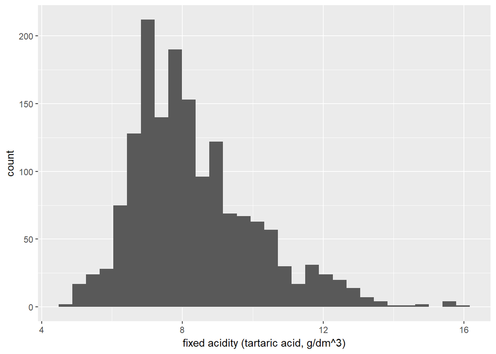

```
##    Min. 1st Qu.  Median    Mean 3rd Qu.    Max.
##    4.60    7.10    7.90    8.32    9.20   15.90
```

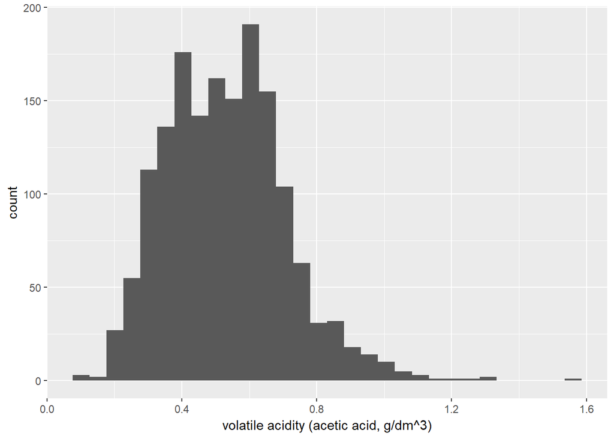

```
##    Min. 1st Qu.  Median    Mean 3rd Qu.    Max.
##  0.1200  0.3900  0.5200  0.5278  0.6400  1.5800
```

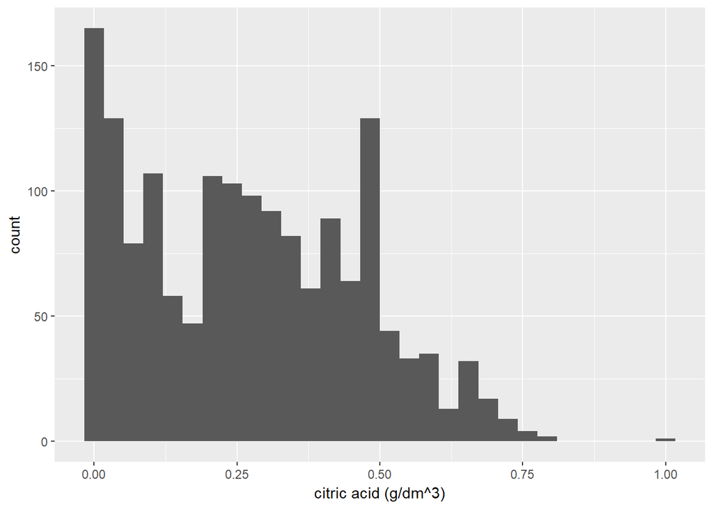

```
##    Min. 1st Qu.  Median    Mean 3rd Qu.    Max.
##   0.000   0.090   0.260   0.271   0.420   1.000
```

The amount of tartaric acid (fixed acidity) in the wines is roughly a order of magnitude greater (4.6-15.9 g/dm^3) than the amount of acetic acid (volatile acidity) (0.12-1.58 g/dm^3) or citric acid (0.0-1.0 g/dm^3).

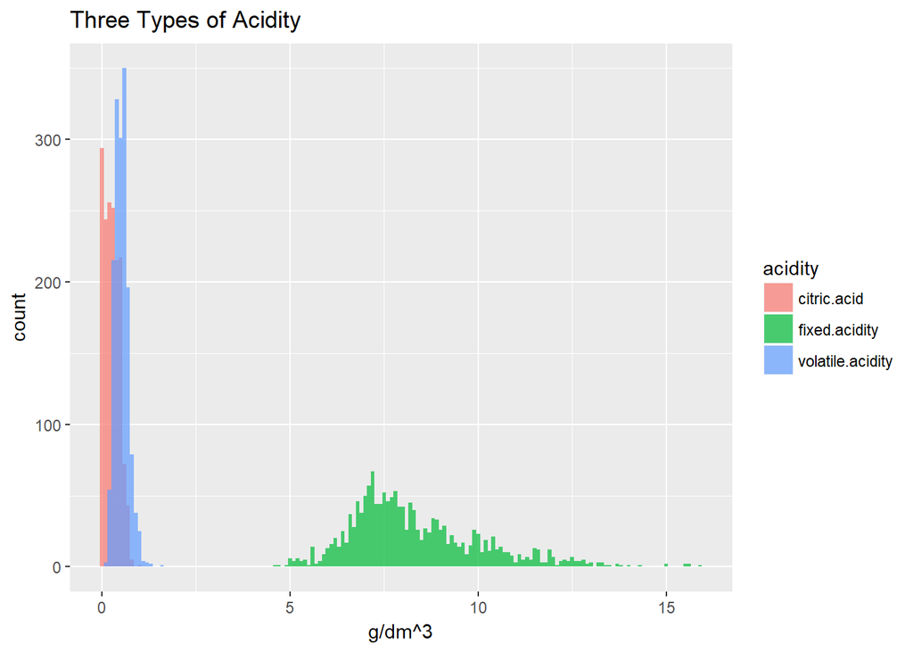

Here we can see how the amounts of each type of acidity relate in frequency.

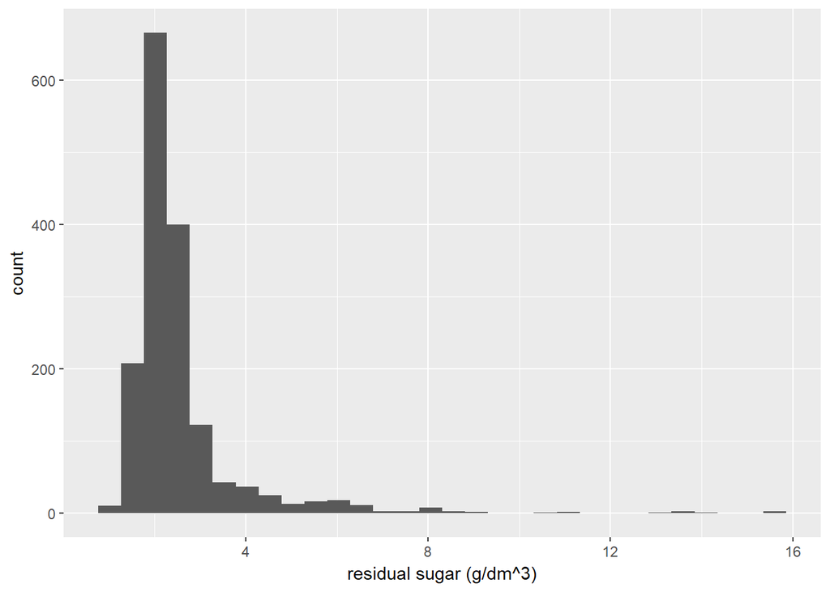

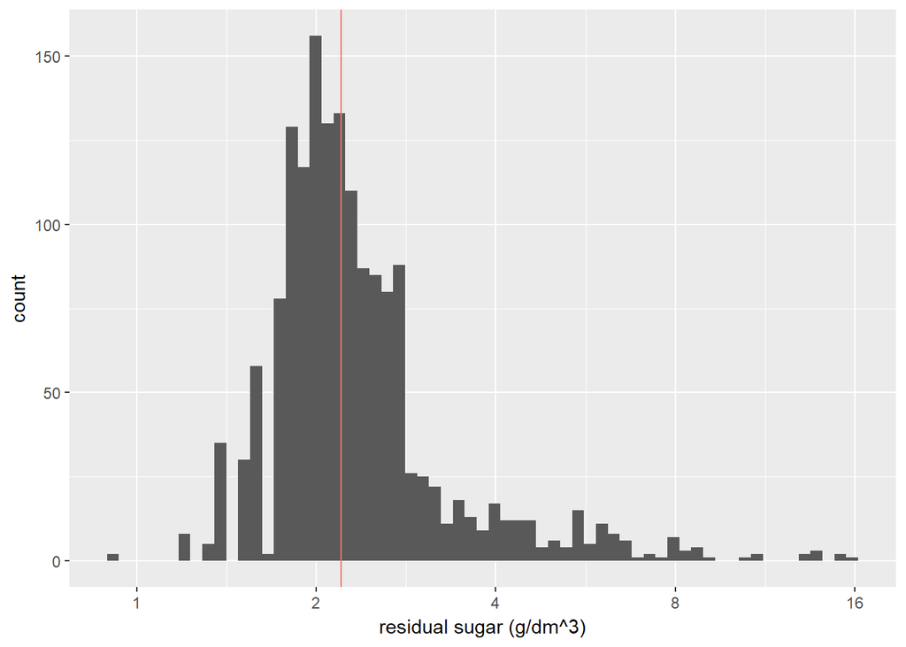

```
##    Min. 1st Qu.  Median    Mean 3rd Qu.    Max.
##   0.900   1.900   2.200   2.539   2.600  15.500
```

Transformed the long tail data to get a better look at what is going on. The median is 2.2 g/dm^3, and has been marked in red. And even using a log_10 scale, the data is still skewed to the right.

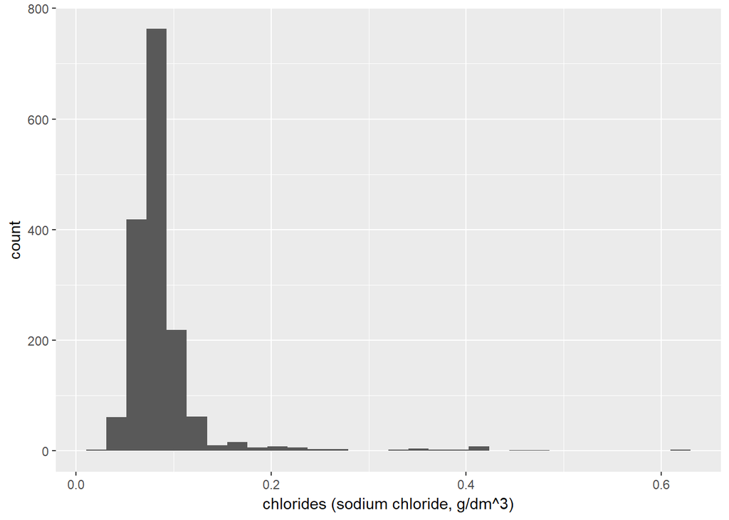

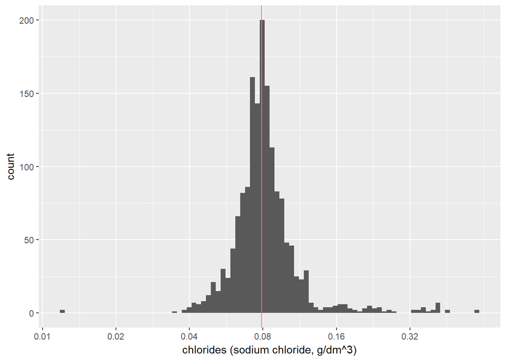

```
##    Min. 1st Qu.  Median    Mean 3rd Qu.    Max.
## 0.01200 0.07000 0.07900 0.08747 0.09000 0.61100
```

Here again, I transformed the long tail data, which looks much closer to normal. However, it still is skewed to the right. The median is 0.07900, which is marked in red.

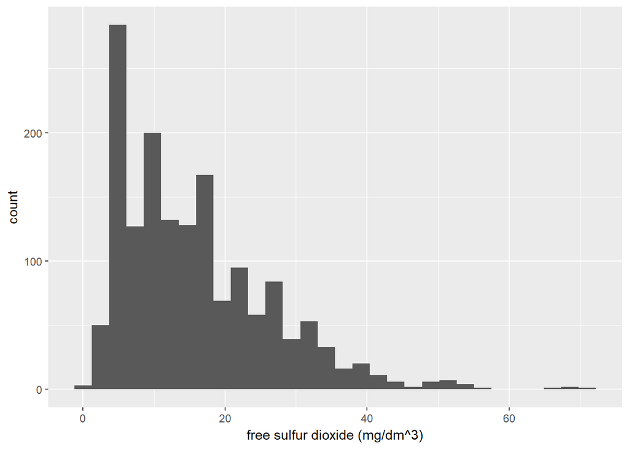

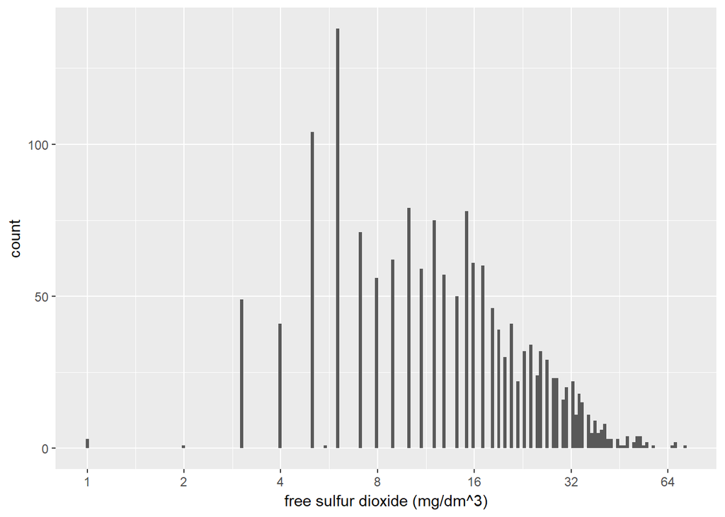